# ZFS

В данном документе представлены результаты исследований исходников ZFSonLinux-0.6.5.4. В некоторых случаях используются иллюстрации из презентаций и документов Oracle, OpenSolaris, FreeBSD. Это используется в тех случаях, когда документация из других реализаций ZFS не конфликтует с ZoL.

## Термины и сокращения

Обратите внимание, к примеру, на разницу между zfs и ZFS:

- ZFS - под этим термином понимается вся система;
- zfs - только файловая система в ZFS (которая опирается на ZPL);
- ZPL - (ZFS POSIX Layer) подсистема, предоставляющая API для работы файловой системы zfs;
- ZVOL - подсистема блочных устройств. В некоторых случаях является синонимом фразы "объект типа DMU_OT_ZVOL";
- zvol - блочное устройство, выделяемое из пула в виде датасета.
- vdev (VDEV) - узел дерева, из которого состоит пул. Если узел является листовым, то это реальное устройство, если нет - виртуальное (mirror, raidz etc);
- SPA - (Storage Pool Allocator) - подсистема, отвечающая за управление занятым/свободным местом в пуле. Оперирует указателями на блоки (blkptr);
- blkptr (BP,БП) - указатель на область/области диска. Может быть пустым (HOLE) и заполненным (FILL);
- ZIO - (ZFS I/O) - подсистема ввода/вывода. Управляет процессом записи/чтения данных с дисков;
- ARC - (Adaptive Replacement Cache) - подсистема, отвечающая за кэширование данных. Через неё проходят все запросы к ZIO;
- arc, l2arc - кэш на чтение первого (память) и второго уровня (диски).
- DMU - (Data Managment Unit) - подсистема, оперирующая объектами ZFS, которые в свою очередь опираются на blkptr'ы. Все объекты описываются при помощи dnode-стуртуры.
- dnode (DN) - (data node) - структура, описывающая некий объект ZFS.
- `*_phys` - суффикс, который соответствует OnDisk-формату. Например, `dnode_phys`, `objset_phys`;
- OnDisk-формат - формат хранения данных непосредственно на физических носителях);
- DSL - (Datasets and Snapshots Layer) - подсистема, оперирующая датасетами и снапшотами. Опирается на DMU.
- ZIL - (ZFS Intent Log) - подсистема, необходимая для обработки синхронных запросов на запись. Может быть представлена в виде устройства SLOG (LogZilla, кэш на запись).
- ZAP - (ZFS Attibute Processor) - подсистема, необходимая для хранения свойств (аттрибутов) различных объектов ZFS, например, свойства файлов или датасетов.
- TXG - (Transaction Group) - группа транзакций. Используется в DMU.
- DBUF - (DMU Buffer) - подсистема, отвечающая за транзакционную запись и COW-механизм.
- Uberblock - блок данных на диске, характеризующий состояние системы на определённый момент времени (точнее - для определённой транзакционной группы).
- ZFS Label - метка на диске/разделе, по которой определяется принадлежность к ZFS.
- `Metaslab, Metaslab Group, Metaslab Class` - объекты, отвечающие за выделение места на в пуле. Хранят информацию о свободном/занятом месте. Имеют OnDisk-формат. Относятся к SPA.
- Indirect blocks - косвенные блоки;
- DVA - (Device Virtual Address) - 128-битный адрес, определяющий область на vdev'е, расположенную по заданному смещению и имеющую заданный размер;
- Gang block - набор блоков небольшого размера, которые предствляются как единый блок. Используются в случае сильной фрагментации;
- BIO (Block IO) - подсистема блочного ввода/выовда ядра Linux;
- NVPair (NVList) - списки пар имя-значение;
- guid - GUID;
- shift - логарифм по основанию 2 для некоторого значения. Например, утверждение "block shift = 9" эквивалентно утверждению "block size = 512b".
- P2PHASE, P2ROUNDUP, P2ALIGN - битовые операции (округление вниз, округление вверх, выравнивание по степеням двойки);
- MOS (Meta Object Set) - объект содержащий информацию о пуле. TODO: уточнить.
- `MetaNode` - метаобъект в датасете или пуле. Содержит в себе дерево, листья которого указывают на объекты датасета/пула. Всегда имеет номер 0;

Часть из предствленных термиров изображена на рис. 1.

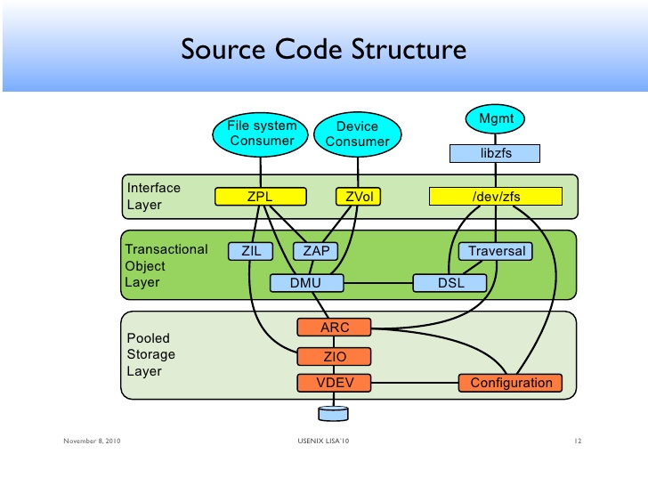

Figure 1. Диаграмма исходного кода ZFS

## ZFS Label

В данном разделе описаны особенности меток ZFS, и свзязанных с ними процессов.

Метки ZFS присутствуют на физическом носителе, если на него производится запись данных (обычные диски в raidz, mirros и slog). Для повышения надёжности на диске присутствуют 4 метки - две в начале диска и две в конце (по номерам, соответственно, 1, 2 и 3, 4). Кроме того, при обновлении данных в метках вначале обновляются первая и третья, а потом - вторая и четвёртая. Это также повышает отказоустойчивость: если произошла ошибка при записи одной из пар, то может использоваться другая пара.

Рассмотрим структуры меток (рис. 2). В каждой метке присутствуют NVList с описанием конфигурации пула и массив уберблоков. Перед первой парой меток дополнительно отступается свободное пространство (8k) под EFI-метки и место под `Boot Block Header` (8k). В текущей реализации `Boot Block Header` просто заполняется нулями с контрольной суммой от этих нулей при создании меток.

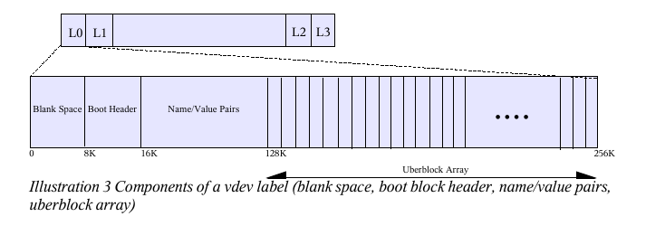

Figure 2. Структура метки ZFS

### Виртуальные устройства (VDEV) и метки на них

Table 1. Типы виртуальных устройств пула

| Тип vdev | Описание | Тип узла | Тип метки |
| --- | --- | --- | --- |
| disk | физическое устройство, на котором хранятся данные | leaf | self |
| file | файл, на котором хранятся данные | leaf | self |
| log | кэш на запись | leaf/internal | property |
| cache | кэш на чтение | aux | aux |
| mirror | RAID-массив | internal | self/children |
| raidz | RAID-массив | internal | self/children |
| missing | устройство, не найденное во время импорта | leaf | None |
| root | корневой vdev пула | root | all |
| spare | устройство для горячей замены | aux | aux |

В табл. 1 представлено описание виртуальных устройств, из которых может состоять пул. Если исходить из практических соображений (возможностей команды `zpool`), то дерево vdev'ов в предельном случае может состоять из:

- корень `root` (root vdev);
- промежуточные узлы `internal` (mirror, raidz);
- листовые узлы `leaf` (disk, file);
- `aux`-устройства (spare, cache);

- leaf - листовые узлы (disk, file);
- top-level vdev - промежуточные узлы (mirror, raidz);
- root - корневой vdev пула;
- aux - устройства, не хранящие данные (cache и spare);
- log - листовой или промежуточный узел, у которого выставлен флаг `is_log`;

Рассмотрим рис. 3. В нём представлен RAID10 пул с RAID1-кэшем на запись. Выделенная штриховкой область - vdev'ы, состояние которых будет отражено в метках устройств `sdq1` и `sdq2`. Желтым выделен vdev, у которого установлен флаг `is_log`. Если бы лог-устройство было бы не зеркалом, а обычными дисками или страйпами, то соответсвующий флаг был бы установлен у них.

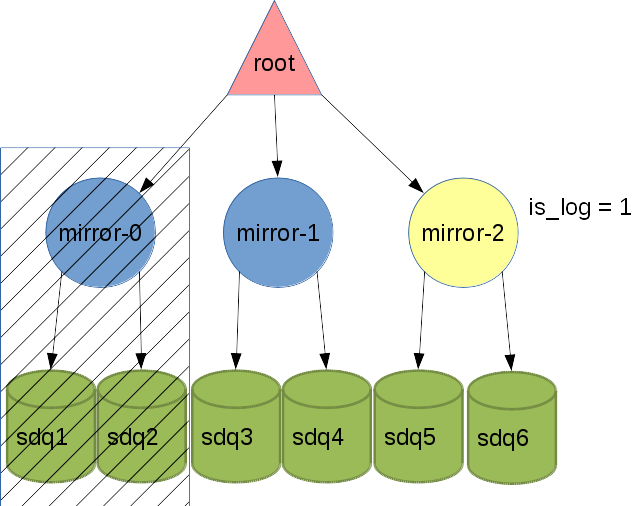

Figure 3. Гибридный пул RAID10 + log(RAID1)

Таким образом, в метках, хранящихся на дисках/файлах отражено состояние данного "листового" vdev'a, его "братьев" и родителя. А также индекс родителя в массиве `root.vdev_tree` (где root - корневой vdev пула).

Пусть мы создаём следующий пул (см. рис 3):

```bash
zpool create -f tank \
    mirror /dev/sdq1 /dev/sdq2 \
    mirror /dev/sdq3 /dev/sdq4 \
    log mirror /dev/sdq5 /dev/sdq6 \
    cache /dev/sdq7 /dev/sdq8 \
    spare /dev/sdq9
zpool status
#  pool: tank
# state: ONLINE
#  scan: none requested
#config:
#
#        NAME        STATE     READ WRITE CKSUM
#        tank        ONLINE       0     0     0
#          mirror-0  ONLINE       0     0     0
#            sdq1    ONLINE       0     0     0
#            sdq2    ONLINE       0     0     0
#          mirror-1  ONLINE       0     0     0
#            sdq3    ONLINE       0     0     0
#            sdq4    ONLINE       0     0     0
#        logs
#          mirror-2  ONLINE       0     0     0
#            sdq5    ONLINE       0     0     0
#            sdq6    ONLINE       0     0     0
#        cache
#          sdq7      ONLINE       0     0     0
#          sdq8      ONLINE       0     0     0
#        spares
#          sdq9      AVAIL
#
#errors: No known data errors
```

Информация о структуре пула будет отражена только в метках дисков `sdq[1-6]`. О дисках `sdq[7-9]` на этих метках не будет никакой информации, т.к. эти диски относятся к типу `aux` `vdev`. `aux`-устройства хранят в своих метках только 3 составляющие: версия пула, тип устройства и guid устройства. Каким же образом ZFS узнаёт, где их искать при импорте? Ответ на этот вопрос - в метаданных пула. Именно там и хранятся пути к этим устройствам. Таким образом, при импорте, на этапе анализа меток aux-устройства не участвуют в "сборе" дерева пула. Это происходит уже после получения `uberblock`'a и чтения метаданных (MOS). В дополнение к этому, ZFS спокойно относится к созданию пулов в которых присутствуют устройства с `aux`-метками (нет необходимости в ключе `-f` для команды `zpool`). Более того, при импорте на этих устройствах затираются данные - ZFS пишет туда свои метки и ей безразлично, хранится ли там информация.

### Конфигурация пула (ZFS Label NVList)

В NVList хранится информация о пуле и части соседних с текущим vdev'ов. Как было раннее указано, хранится информация только о важных (с точки зрения целостности данных) vdev'ах - диски с данными и slog. Другие виды vdev'ов (l2cache, spare) хранятся вне меток (непосредственно внутри пула). "Соседние" vdev'ы - те устройства (виртуальные и реальные) с которыми граничит данное устройство в дереве vdev'ов пула. Именно о них и хранится информация в метке диска/файла. Одна из составляющих метки - список конфигурационных параметров пула. NVList конфигурации пула включает в себя следующие элементы:

- версия OnDisk-формата;
- имя пула;
- состояние пула (активный, экспортированный, уничтоженный);
- номер транзакционной группы, в которой была записана метка;
- guid пула;
- guid vdev'а верхнего уровня;
- дерево соседних vdev'ов;

Дерево vdev'ов содержит элементы - массив, состоящий из элементов:

- type: имя типа (диск, файл, зеркало и т.п.);
- id: уникальный индекс vdev'а в родительском vdev'е;
- guid vdev'a;
- path: путь к устройству (только для "листовых" vdev'ов - диски, файлы)
- metaslab_array: номер объекта (внутри пула), который содержит массив номеров объектов, каждый из которых соответствует объекту, описывающему metaslab;
- metaslab_shift: log2 от размера метаслаба;
- ashift (allocatable shift): log2 от размера минимальной области, которая может быть выделена в top-level vdev'е. Например, если ashift=9, то в данном vdev'е области будут выделяться не меньшие, чем 512 байт;
- asize (allocatable size): количество байт, которое можно выделить в данном vdev'е. Грубо говоря, общий объем всех дочерних vdev'ов;
- children: список дочерних vdev'ов;

### Уберблоки (Uberblocks)

Следующий элемент метки - уберблоки (Uberblocks). В текущей реализации используется массив из 128 уберблоков. Размер уберблока - 1k. ZFS работает с уберблоками как с кольцевым буффером: при обновлении перезаписывается самый старый уберблок. Таким образом, теоретически, мы в любой момент времени имеем до 128 readonly состояний файловой системы (на самом деле меньше - см. раздел метаслабы). При поиске уберблока (во время операции импорта) выбирается уберблок, соответствующий следующим критериям:

- верная контрольная сумма;
- наибольшее значение временной метки;
- наибольшее значение номера транзакционной группы;

Уберблок состоит из следующих элементов:

- ub_magic: уникальное "магическое" число (magic number), которое позволяет не только определить, что область на диске содержит уберблок, но определить порядок байт, определённый в пуле (ZFS пулы переносимы между системами с различными `endianness`):
  - Big-Endian: 0x00bab10c (oo-ba-block)
  - Little-Endian: 0xcb1ba00
- ub_version: версия OnDisk-формата (см. версию в NVList)
- ub_txg: номер транзакционной группы, в которой был записан данный уберблок. Должен быть не меньше, чем параметр `txg` в метке;
- ub_guid_sum: сумма guid всех листовых vdev'ов. Используется для проверки доступности всех vdev'ов пула. Если это поле не совпадает с вычисленной при импорте суммой, значит было потеряно устройство;
- ub_timestamp: временная метка на момент записи уберблока;
- ub_rootbp: blktr, указывающий на расположение MOS (Meta Object Set) данного пула;

### Просмотр меток

Для просмотра содержимого меток пула можно воспользоваться командой `zdb <pool-name>`. Или `zdb <pool-name> -e -p <dir>` если пул был экспортирован и файлы/диски, из которых состоит пул находятся в директории `<dir>`.

## Указатели на блоки (Block Pointers)

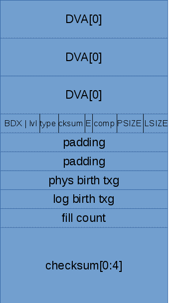

Figure 4. Структура blkptr_t

На рис. 5 представлена структура DVA (Device Virtual Address). Она состоит из следующих элементов:

- asize (allocated size): размер данных (в единицах ashift vdev'а верхнего уровня), на которые указывает данный BP. Стоит отметить, что данный параметр имеет наибольший размер (в битах) по отношению к LSIZE и PSIZE (см. поля BP), т.к. дополнительно может понадобиться место для хранения данных GANG-блоков, RAIDZ и 3-х DVA на один BP.
- grid: зарезервировано для raidz;
- vdev: уникальный номер vdev'а в пуле;
- offset: смещение в единицах ashift, которое характеризует расположение блока в пуле (*p**h**y**s**a**d**d**r* = (*o**f**f**s**e**t* ≪ *a**s**h**i**f**t*)+*L**a**b**e**l*<sub>*s**i**z**e*</sub>, где *L**a**b**e**l*<sub>*s**i**z**e*</sub> = 4*M**B* = 0.5МБ отступ первых 2-х меток + 3.5МБ свободного места)
- G (Gang): флаг, характиризующий, является ли блок Gang-блоком (0 - нет, 1 - да).

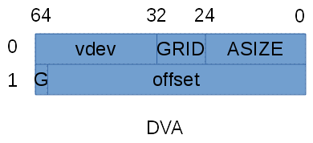

Структура DVA (5)

Как было отмечено выше, в BP может содержаться до 3-х DVA. Это значит, что один BP может ссылаться на данные в 3-х различных местах пула. Это сделано для повышения надёжности хранения данных, в особенности - метаданных. Ведь потеря метаданных (например, косвенного блока или dnode'ы) может оказать существенное влияние на целостность данных в пуле. К примеру, если мы "потеряем" данные, на которые указывает `ub_rootbp` уберблока, то мы потеряем все данные. Чтобы не допустить это, используется избыточность для метаданных. Количество избыточных DVA зависит от вида BP (данные/метаданные) и типа метаданных (чем выше по дереву - тем большая избыточность). На рис. 6-7 изображены примеры количества и расположения блоков на различных видах пулов.

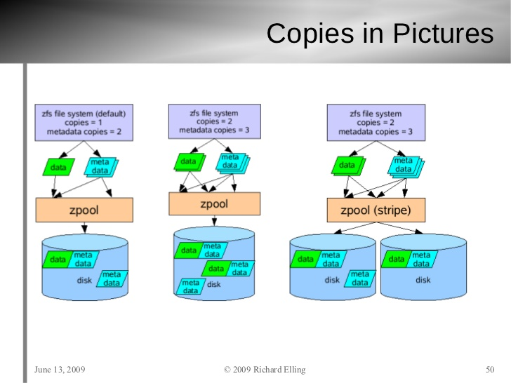

Избыточность BP(6)

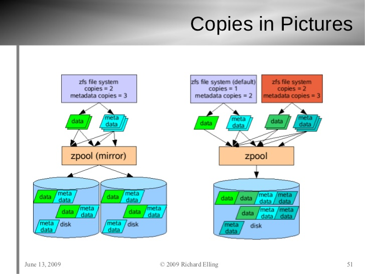

Избыточность BP(7)

Избыточность по DVA задаётся посредством параметра `copies` в свойствах датасета (для существующего датасета выполнение команды `zfs set <pool/ds> copies=N` приведёт к тому, что новые данные будут дублироваться, однако на старые блоки это не окажет влияния. Также этот параметр можно задавать при создании датасета).

Рассмотрим подробнее поля bklptr_t, представленные на рис. 4:

- `DVA[3]`: 3 128-битных адреса;
- B (byteorder, endianness): флаг, определяющий порядок байт;
- D (dedup): флаг, определяющий наличие дедупликации;
- X (encryption): флаг, определяющий наличие шифрования (в текущей версии не поддерживается);
- lvl (indirection level): уровень косвенности для косвенных блоков. Блоки, указывающие на данные содержат значение 0 (`L0`).
- type: тип объекта, к которому относится данный BP (см. ниже, константы вида `DMU_OT_*`);
- cksum: тип контрольной суммы и включена ли она. Значение этого поля интерпретируется в зависимости от типа блока;
- E: флаг, определяющий, является ли BP встроенным (embedded BP, см. ниже). В старых версиях ZFS отсутствует;
- comp: тип компрессии и включена ли она;
- padding: неиспользуемые/зарезервированные поля (пока что используются в целях выравнивания);
- phys birth txg (physical birth txg): номер транзакции, в результате которой было выделено место под данные, на который указывает данный BP. В случае, если phys birth txg == 0, то считается, что блок был данных был выделен в тот же момент, когда появился данный BP (т.е. phys birth txt == log birth txt).
- log birth txg (logical birth txg): номер транзакции, в результате которой появился данный BP;
- fill count: количество заполненных блоков, которые находятся ниже данного в дереве косвенных блоков. Для блока, указывающего на данные (`L0`) fill count всегда равен 1;
- `checksum[4]`: значение контрольной суммы данного блока;

### Косвенные блоки (indirect blkptr) и размеры блоков

Размеры BP, как правило, ограничены параметрами датасетов `volblocksize (zvol)` и `recordsize (zfs)`. В свою очередь, на эти параметры накладываются следующие ограничения:

- blocksize не может быть меньше, чем `ashift` (невозможно выделить блоки, меньшие, чем размер логического блока дисков пула);
- blocksize не может быть больше, чем `zfs_max_recordsize` (параметр модуля ядра);

Параметр `zfs_max_recordsize` по умолчанию равен 1М, максимальное значение - 16M. Теоретический максимум этого значения равен максимальному значению поля `LSIZE * ashift` в BP (т.е. 32M), однако поле `dn_datablkszsec` может хранить не более, чем `32M - 512` байт. Поэтому максимум `zfs_max_recordsize` ограничен 16МБ (P2PHASE от 32M - 512).

В случае, если возникает необходимость хранения данных больших, чем размер блока, необходимы косвенные блоки (indirect blocks). Косвенные блоки образуют дерево косвенных блоков (рис. 8). На каждый узел дерева выделяется место, равное `DNODES_PER_BLOCK` (в данный момент - 16k). Учитывая размер blkptr равный 128B, в косвенный блок может содержать до 128 указателей на блоки. Место под косвенные блоки выделяется сразу и заполняется по мере наполнения соответствующего узла.

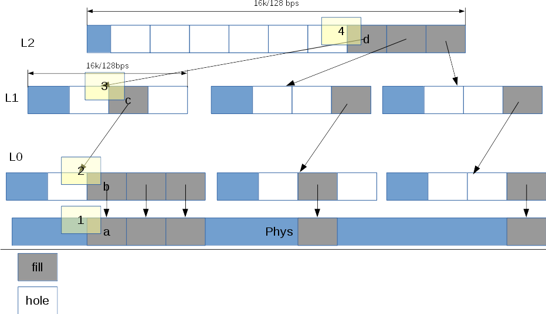

Дерево косвенных блоков (8)

### Заполненность блоков (fill/hole)

Каждый blkptr может либо указывать на данные (в случае, если в хотя бы один DVA в нём ненулевой), либо быть "дыркой" (HOLE) - пустой указатель. В ранних версиях пустые указатели имели все поля, равные нулю. В новых версиях пулов, в которых включена фича "hole_birth" у данного вида указателей присутствует поле birth txg, которое характеризует время (номер транзакционной группы) появления данного указателя. Данная фича позволяет сократить объем данных, пересылаемых при помощи `zfs send|recv`.

### Встраиваемый BP (embedded blkptr)

Ещё одна фича новых пулов - "embedded_data". Это особый вид BP, которые содержат данные в самих себе. Это сделано для того, чтобы уменьшить время доступа к мелким блокам: вместо того, чтобы идти по адресу, содержащемся в DVA, мы можем сразу считать данные из полей BP. Данный вид BP имеет структуру, отличную от обычных BP, кроме того, запись таких блоков производится иначе.

### Gang-блоки (Gang Blocks)

Как было замечено выше, в случае, если ZFS не может выделить места, достаточного для блока, она выделяет несколько блоков меньшего размера, и оперирует ими как одним целым. Так же, как и embedded BP, Gang-блоки имеют несколько иное поведение при операциях ввода/вывода.

### Типы объектов ZFS

Одно из полей `blkptr_t` - `type` характеризует тип объекта, к которому относится данный BP. В табл. 2 представлены несколько таких типов.

Некоторые виды DMU объектов (2)

| Название типа | Описание/тип |
| --- | --- |
| DMU_OT_NONE | - |
| General types: |  |
| DMU_OT_OBJECT_DIRECTORY | Объект ZAP |
| DMU_OT_OBJECT_ARRAY | UINT64 |
| DMU_OT_PACKED_NVLIST | UINT8 (XDR-кодированный nvlist) |
| DMU_OT_PACKED_NVLIST_SIZE | UINT64 |
| DMU_OT_BPOBJ, | UINT64 |
| DMU_OT_BPOBJ_HDR, | UINT64 |
| SPA types: |  |
| DMU_OT_SPACE_MAP_HEADER | UINT64 |
| DMU_OT_SPACE_MAP | UINT64 |
| ZIL types: |  |
| DMU_OT_INTENT_LOG | UINT64 |
| ZVOL types: |  |
| DMU_OT_ZVOL | UINT8 |
| DMU_OT_ZVOL_PROP | Объект ZAP |

Например, в датасете `zvol` присутствует 2 объекта - `ZVOL` и `ZVOL_PROP`. Первый объект относится к данным, которые представляет `zvol`, второй - свойства `zvol`'а (например, `volblocksize`). Все BP, на которые прямым и косвенным образом ссылается первый объект в поле `type` будут содержать значение `DMU_OT_ZVOL`.

## Объекты и слой DMU

В данном пункте будут подробно рассмотрены объекты `ZFS`, т.к. они составляют большую часть системы и являются абстракцией, упрощающей работу с `BP`.

Основной структурой, связанной с объектами является `dnode`, которая представлена в `OnDisk`-формате в виде `dnode_phys`. Рассмотрим её основные поля:

- `dn_type`: тип объекта, с которым связана данная DN (`dmu_object_type_t`);
- `dn_indblkshift`: log2 от `indirect block size` - размера косвенных блоков;
- `dn_nlevels`: число уровней косвенности. Если 1, то `dn_blkptr` указывает на блоки данных;
- `dn_nblkptr`: длина поля dn_nblkptr (точнее - количество задействованных указателей). Значения - от 1 до 3;
- `dn_bonustype`: тип данных в bonus-буффере;
- `dn_checksum`: тип контрольной суммы (`enum zio_checksum`);
- `dn_compress`: тип сжатия (`enum zio_compress`);
- `dn_flags`: флаги
  - `DNODE_FLAG_USED_BYTES (1<<0)`: dn_used использует байты? если нет, то `dn_used` в качестве единиц использует `SPA_MINBLOCKSIZE` (512b)
  - `DNODE_FLAG_USERUSED_ACCOUNTED (1<<1)`
  - `DNODE_FLAG_SPILL_BLKPTR (1<<2)`: имеет ли данный объект системные аттрибуты в bonus-буффере
- `dn_datablkszsec`: размер блока данных в 512b секторах;
- `dn_bonuslen`: длина dn_bonus (bonus-буффер в объединении dn_nblkptr);
- `dn_pad2[4]`: зарезервировано/дополнение для выравнивания
- `dn_maxblkid`: наибольший ID выделенного блока
- `dn_used`: объём используемого дискового пространства (в байтах или секторах в зависимости от `dn_flags`)
- `dn_pad3[4]`: зарезервировано/дополнение для выравнивания
- `dn_blkptr`: объединение, которое может использоваться тремя различными способами:

  ```
  0       64      128     192     256     320     384     448 (offset)
  +---------------+---------------+---------------+-------+
  | dn_blkptr[0]  | dn_blkptr[1]  | dn_blkptr[2]  | /     |
  +---------------+---------------+---------------+-------+
  | dn_blkptr[0]  | dn_bonus[0..319]                      |
  +---------------+-----------------------+---------------+
  | dn_blkptr[0]  | /                     | dn_spill      |
  +---------------+-----------------------+---------------+
  ```

### MOS

Meta Objset пула - метаобъект (контейнер объектов) пула, в котором содержится дополнительная информация о конфигурации пула, директории датасетов (DSL directory), карты датасетов (DSL child map), метаобъекты датасетов (Dataset), метаслабы, карты пространств и другие виды объектов. Пример получения доступа к датасету: `MOS -> object=1.root_dataset -> ... linked list ... -> DSL directory (parent) -> DSL directory (child) -> "DSL dataset".bp -> Dataset`

### Косвенные блоки и объекты

dnode предоставляет механизмы работы с косвенными блоками. Рассмотрим датасет типа ZVOL. После создания он состоит из следующих компонентов:

- Meta Node (можно получить через макрос `DMU_META_DNODE(objset)`), номер объекта равен 0;
- `ZVOL`-объект, номер объекта равен 1;
- `ZVOL_PROP`-объект, номер объекта равен 2;

Рассмотрим объект `Meta Node`. Данный объект представляет собой дерево из *l**e**v**e**l**s* уровней. Значение *l**e**v**e**l**s* = *l**v**l* должно удовлетворять следующему условию:

*n**b**l**k**p**t**r* * 2<sup>(*d**a**t**a**b**l**k**s**h**i**f**t* + (*l**v**l* − 1)*(*i**n**d**b**l**k**s**h**i**f**t* − *B**P**S**H**I**F**T*))</sup> > =*M**A**X*_*O**B**J**E**C**T* * *s**i**z**e*<sub>*d**n**o**d**e*</sub>  
, где

- `nblkptr`, `datashift`, `indblkshift` - соответствующие поля структуры `dnode`;
- `BPSHIFT (SPA_BLKPTRSHIFT)` - размер структуры blkptr_t (128b);
- `MAX_OBJECT (DN_MAX_OBJECT)` - максимальный размер объекта (2<sup>48</sup> байт);
- *s**i**z**e*<sub>*d**n**o**d**e*</sub> - размер структуры `dnode_phys` в байтах;

Если выполнить преобразования:

- Размер блока данных в байтах: *b**l**k**s**i**z**e* = 2<sup>*d**a**t**a**b**l**k**s**h**i**f**t*</sup>;
- Количество BP, которые можно разместить в одном косвенном блоке: *i**n**d*_*p**e**r*_*b**p* = (2<sup>*i**n**d*</sup>)/(2<sup>*B**P**S**H**I**F**T*</sup>);
- Максимальный размер объекта, состоящего из `dnode_phys` в байтах: *m**a**x*_*o**b**j* = *M**A**X*_*O**B**J**E**C**T* * *s**i**z**e*<sub>*d**n**o**d**e*</sub>;

То получим:

*n**b**l**k**p**t**r* * *b**l**k**s**i**z**e* * *i**n**d*_*p**e**r*_*b**p*<sup>*l**v**l* − 1</sup> > =*m**a**x*_*o**b**j*

Учитывая, что количество элементов в дереве на глубине *l**v**l* равно *i**n**d*_*p**e**r*_*b**p*<sup>*l**v**l*</sup>, то неравенство отражает тот факт, дерево должно быть достаточной глубины, для того, чтобы вместить в себя метаобъект максимально возможного размера. Например, `dnode`, в котором `levels = 3` и `dn_nblkptr = 2` может оперировать с объектом, который состоит из 2 * 128<sup>3 − 1</sup> блоков (128 - количество косвенных блоков, умещающихся на одном уровне).

`MetaNode` (объект с нулевым индексом) содержит в себе все объекты датасета. В случае `ZVOL`-датасета, там хранятся два объекта `DMU_OT_ZVOL` и `DMU_OT_ZVOL_PROP`.

В объекте `DMU_OT_ZVOL` также могут использоваться косвенные блоки.

Важно отметить, что в объекте `MetaNode` хранится дерево, состоящее из `dnode_phys`, а в качестве ссылок на узлы используются указатели `dnode_phys.dn_blkptr`. А в объекте типа `ZVOL` дерево состоит только из `blkptr_t`, в качестве ссылок там используются `DVA` (см. рис. 8).

Рассмотрим алгоритм обхода косвенных блоков (из zdb.c):

```c
void traverse_indirect(int objset, int object, int level, int blkid, bp) {
    // level: N
    // objset:  number in parent MetaNode object tree
    // bp:  current bp with level = L(N)
    blkptr_t *cbp; // child bp with level = L(N - 1)

    do_something(bp);

    if (BP_GET_LEVEL(bp) > 0 && !BP_IS_HOLE(bp)) {
        arc_buf_t *buf;
        // element per block = bp.lsize / sizeof(bp)
        int epb = BP_GET_LSIZE(bp) >> SPA_BLKPTRSHIFT;
        buf = arc_read(bp); //pseudo-code
        for(i = 0; i < epb; i++, cbp++)
        {
            traverse_indirect(
                objset,
                object,
                level - 1,
                blkid * epb + i,
                cbp
            );
        }

    }

}
```

На рис. 9 изображено дерево, из которого состоит объект `DMU_OT_DNODE`. Если сравнить его с деревом blkptr (рис. 8), то заметно два отличия: корень и листья в метаобъекте являются элементами `dnode_phys`. На корень этого дерева указывает объект типа dataset из метаданных пула. А листья - указывают на объекты (метаданные) самого датасета.

[figure not shown]

Структура мета-объекта (9)